# Coursework

```python
import os
import pandas as pd
import numpy as np
import matplotlib.pyplot as mpp
import warnings
warnings.filterwarnings('ignore')
```

```python
os.getcwd()
```

```
'E:\\College\\Year 2\\Sem 2\\SDD\\Coursework\\Sales Files'
```

```python
cd E:\College\Year 2\Sem 2\SDD\Coursework\Sales Files
```

```
E:\College\Year 2\Sem 2\SDD\Coursework\Sales Files
```

```python
os.getcwd()
```

```
'E:\\College\\Year 2\\Sem 2\\SDD\\Coursework\\Sales Files'
```

```python
os.listdir()
```

```
['Sales_April_2019.csv',
 'Sales_August_2019.csv',
 'Sales_December_2019.csv',
 'Sales_February_2019.csv',
 'Sales_January_2019.csv',
 'Sales_July_2019.csv',
 'Sales_June_2019.csv',
 'Sales_March_2019.csv',
 'Sales_May_2019.csv',
 'Sales_November_2019.csv',
 'Sales_October_2019.csv',
 'Sales_September_2019.csv']
```

##### Write a python program to merge data from each month into one CSV and read in updated dataframe

```python
dataFrame =pd.DataFrame()
for each in os.listdir():
    if each.endswith('.csv'):
        dataFrame = dataFrame.append(pd.read_csv(each))
dataFrame
```

|  | Order ID | Product | Quantity Ordered | Price Each | Order Date | Purchase Address |
| --- | --- | --- | --- | --- | --- | --- |
| 0 | 176558.0 | USB-C Charging Cable | 2.0 | 11.95 | 4/19/2019 8:46 | 917 1st St, Dallas, TX 75001 |
| 1 | NaN | NaN | NaN | NaN | NaN | NaN |
| 2 | 176559.0 | Bose SoundSport Headphones | 1.0 | 99.99 | 4/7/2019 22:30 | 682 Chestnut St, Boston, MA 02215 |
| 3 | 176560.0 | Google Phone | 1.0 | 600.00 | 4/12/2019 14:38 | 669 Spruce St, Los Angeles, CA 90001 |
| 4 | 176560.0 | Wired Headphones | 1.0 | 11.99 | 4/12/2019 14:38 | 669 Spruce St, Los Angeles, CA 90001 |
| ... | ... | ... | ... | ... | ... | ... |
| 11681 | 259353.0 | AAA Batteries (4-pack) | 3.0 | 2.99 | 9/17/2019 20:56 | 840 Highland St, Los Angeles, CA 90001 |
| 11682 | 259354.0 | iPhone | 1.0 | 700.00 | 9/1/2019 16:00 | 216 Dogwood St, San Francisco, CA 94016 |
| 11683 | 259355.0 | iPhone | 1.0 | 700.00 | 9/23/2019 7:39 | 220 12th St, San Francisco, CA 94016 |
| 11684 | 259356.0 | 34in Ultrawide Monitor | 1.0 | 379.99 | 9/19/2019 17:30 | 511 Forest St, San Francisco, CA 94016 |
| 11685 | 259357.0 | USB-C Charging Cable | 1.0 | 11.95 | 9/30/2019 0:18 | 250 Meadow St, San Francisco, CA 94016 |

186850 rows × 6 columns

##### Write a python program to remove the NaN missing values from updated dataframe

```python
dataFrame[dataFrame.isna().any(axis=1)]
```

|  | Order ID | Product | Quantity Ordered | Price Each | Order Date | Purchase Address |
| --- | --- | --- | --- | --- | --- | --- |
| 1 | NaN | NaN | NaN | NaN | NaN | NaN |
| 356 | NaN | NaN | NaN | NaN | NaN | NaN |
| 519 | NaN | NaN | NaN | NaN | NaN | NaN |
| 735 | NaN | NaN | NaN | NaN | NaN | NaN |
| 1149 | NaN | NaN | NaN | NaN | NaN | NaN |
| ... | ... | ... | ... | ... | ... | ... |
| 11384 | NaN | NaN | NaN | NaN | NaN | NaN |
| 11399 | NaN | NaN | NaN | NaN | NaN | NaN |
| 11468 | NaN | NaN | NaN | NaN | NaN | NaN |
| 11574 | NaN | NaN | NaN | NaN | NaN | NaN |
| 11662 | NaN | NaN | NaN | NaN | NaN | NaN |

900 rows × 6 columns

```python
dataFrame.isna().sum()
```

```
Order ID            900
Product             900
Quantity Ordered    900
Price Each          900
Order Date          900
Purchase Address    900
dtype: int64
```

```python
dataFrame.dropna(inplace=True)
dataFrame
```

|  | Order ID | Product | Quantity Ordered | Price Each | Order Date | Purchase Address |
| --- | --- | --- | --- | --- | --- | --- |
| 0 | 176558.0 | USB-C Charging Cable | 2.0 | 11.95 | 4/19/2019 8:46 | 917 1st St, Dallas, TX 75001 |
| 2 | 176559.0 | Bose SoundSport Headphones | 1.0 | 99.99 | 4/7/2019 22:30 | 682 Chestnut St, Boston, MA 02215 |
| 3 | 176560.0 | Google Phone | 1.0 | 600.00 | 4/12/2019 14:38 | 669 Spruce St, Los Angeles, CA 90001 |
| 4 | 176560.0 | Wired Headphones | 1.0 | 11.99 | 4/12/2019 14:38 | 669 Spruce St, Los Angeles, CA 90001 |
| 5 | 176561.0 | Wired Headphones | 1.0 | 11.99 | 4/30/2019 9:27 | 333 8th St, Los Angeles, CA 90001 |
| ... | ... | ... | ... | ... | ... | ... |
| 11681 | 259353.0 | AAA Batteries (4-pack) | 3.0 | 2.99 | 9/17/2019 20:56 | 840 Highland St, Los Angeles, CA 90001 |
| 11682 | 259354.0 | iPhone | 1.0 | 700.00 | 9/1/2019 16:00 | 216 Dogwood St, San Francisco, CA 94016 |
| 11683 | 259355.0 | iPhone | 1.0 | 700.00 | 9/23/2019 7:39 | 220 12th St, San Francisco, CA 94016 |
| 11684 | 259356.0 | 34in Ultrawide Monitor | 1.0 | 379.99 | 9/19/2019 17:30 | 511 Forest St, San Francisco, CA 94016 |
| 11685 | 259357.0 | USB-C Charging Cable | 1.0 | 11.95 | 9/30/2019 0:18 | 250 Meadow St, San Francisco, CA 94016 |

185950 rows × 6 columns

```python
dataFrame.isna().sum()
```

```
Order ID            0
Product             0
Quantity Ordered    0
Price Each          0
Order Date          0
Purchase Address    0
dtype: int64
```

Write a python program to convert Quantity Ordered and Price Each to numeric.

```python
dataFrame[['Quantity Ordered', 'Price Each']].dtypes
```

```
Quantity Ordered    float64
Price Each          float64
dtype: object
```

```python
dataFrame[['Quantity Ordered', 'Price Each']] = dataFrame[['Quantity Ordered', 'Price Each']].astype(int)
dataFrame[['Quantity Ordered', 'Price Each']].dtypes
```

```
Quantity Ordered    int32
Price Each          int32
dtype: object
```

Create a new column named Month from Ordered Date of updated dataframe and convert it to integer as data type.

```python
dataFrame['Order Date']=pd.to_datetime(dataFrame['Order Date'])
dataFrame['Month']=dataFrame['Order Date'].dt.month.astype(int)
dataFrame
```

|  | Order ID | Product | Quantity Ordered | Price Each | Order Date | Purchase Address | Month |
| --- | --- | --- | --- | --- | --- | --- | --- |
| 0 | 176558.0 | USB-C Charging Cable | 2 | 11 | 2019-04-19 08:46:00 | 917 1st St, Dallas, TX 75001 | 4 |
| 2 | 176559.0 | Bose SoundSport Headphones | 1 | 99 | 2019-04-07 22:30:00 | 682 Chestnut St, Boston, MA 02215 | 4 |
| 3 | 176560.0 | Google Phone | 1 | 600 | 2019-04-12 14:38:00 | 669 Spruce St, Los Angeles, CA 90001 | 4 |
| 4 | 176560.0 | Wired Headphones | 1 | 11 | 2019-04-12 14:38:00 | 669 Spruce St, Los Angeles, CA 90001 | 4 |
| 5 | 176561.0 | Wired Headphones | 1 | 11 | 2019-04-30 09:27:00 | 333 8th St, Los Angeles, CA 90001 | 4 |
| ... | ... | ... | ... | ... | ... | ... | ... |
| 11681 | 259353.0 | AAA Batteries (4-pack) | 3 | 2 | 2019-09-17 20:56:00 | 840 Highland St, Los Angeles, CA 90001 | 9 |
| 11682 | 259354.0 | iPhone | 1 | 700 | 2019-09-01 16:00:00 | 216 Dogwood St, San Francisco, CA 94016 | 9 |
| 11683 | 259355.0 | iPhone | 1 | 700 | 2019-09-23 07:39:00 | 220 12th St, San Francisco, CA 94016 | 9 |
| 11684 | 259356.0 | 34in Ultrawide Monitor | 1 | 379 | 2019-09-19 17:30:00 | 511 Forest St, San Francisco, CA 94016 | 9 |
| 11685 | 259357.0 | USB-C Charging Cable | 1 | 11 | 2019-09-30 00:18:00 | 250 Meadow St, San Francisco, CA 94016 | 9 |

185950 rows × 7 columns

```python
dataFrame['Month'].dtypes
```

```
dtype('int32')
```

Create a new column named City from Purchase Address based on the value in updated dataframe.

```python
dataFrame['City'] = dataFrame['Purchase Address'].str.split(',').str[1]
dataFrame
```

|  | Order ID | Product | Quantity Ordered | Price Each | Order Date | Purchase Address | Month | City |
| --- | --- | --- | --- | --- | --- | --- | --- | --- |
| 0 | 176558.0 | USB-C Charging Cable | 2 | 11 | 2019-04-19 08:46:00 | 917 1st St, Dallas, TX 75001 | 4 | Dallas |
| 2 | 176559.0 | Bose SoundSport Headphones | 1 | 99 | 2019-04-07 22:30:00 | 682 Chestnut St, Boston, MA 02215 | 4 | Boston |
| 3 | 176560.0 | Google Phone | 1 | 600 | 2019-04-12 14:38:00 | 669 Spruce St, Los Angeles, CA 90001 | 4 | Los Angeles |
| 4 | 176560.0 | Wired Headphones | 1 | 11 | 2019-04-12 14:38:00 | 669 Spruce St, Los Angeles, CA 90001 | 4 | Los Angeles |
| 5 | 176561.0 | Wired Headphones | 1 | 11 | 2019-04-30 09:27:00 | 333 8th St, Los Angeles, CA 90001 | 4 | Los Angeles |
| ... | ... | ... | ... | ... | ... | ... | ... | ... |
| 11681 | 259353.0 | AAA Batteries (4-pack) | 3 | 2 | 2019-09-17 20:56:00 | 840 Highland St, Los Angeles, CA 90001 | 9 | Los Angeles |
| 11682 | 259354.0 | iPhone | 1 | 700 | 2019-09-01 16:00:00 | 216 Dogwood St, San Francisco, CA 94016 | 9 | San Francisco |
| 11683 | 259355.0 | iPhone | 1 | 700 | 2019-09-23 07:39:00 | 220 12th St, San Francisco, CA 94016 | 9 | San Francisco |
| 11684 | 259356.0 | 34in Ultrawide Monitor | 1 | 379 | 2019-09-19 17:30:00 | 511 Forest St, San Francisco, CA 94016 | 9 | San Francisco |
| 11685 | 259357.0 | USB-C Charging Cable | 1 | 11 | 2019-09-30 00:18:00 | 250 Meadow St, San Francisco, CA 94016 | 9 | San Francisco |

185950 rows × 8 columns

```python
chosen_Var ='Quantity Ordered'
var_Sum = dataFrame[chosen_Var].sum()
var_Mean = dataFrame[chosen_Var].mean()
var_StandardDeviation = dataFrame[chosen_Var].std()
var_Skewness = dataFrame[chosen_Var].skew()
var_Kurtosis = dataFrame[chosen_Var].kurtosis()
print("Sum: ",var_Sum,"\nStandard Deviation: ",var_StandardDeviation ,"\nMean: ",var_Mean, "\nSkewness: ",var_Skewness, "\nKurtosis: ",var_Kurtosis)
```

```
Sum:  209079
Standard Deviation:  0.44279262402849096
Mean:  1.1243828986286637
Skewness:  4.833164172577953
Kurtosis:  31.82048892027536
```

Write a Python program to calculate and show correlation of all variables.

```python
dataFrame.corr()
```

|  | Order ID | Quantity Ordered | Price Each | Month |
| --- | --- | --- | --- | --- |
| Order ID | 1.000000 | 0.000702 | -0.002861 | 0.993063 |
| Quantity Ordered | 0.000702 | 1.000000 | -0.148335 | 0.000791 |
| Price Each | -0.002861 | -0.148335 | 1.000000 | -0.003379 |
| Month | 0.993063 | 0.000791 | -0.003379 | 1.000000 |

### 4.Data Exploration

Which Month has the best sales? and how much was the earning in that month? Make a bar graph of sales as well.

```python
dataFrame['Sales']=dataFrame['Quantity Ordered']*dataFrame['Price Each']
dataFrame
```

|  | Order ID | Product | Quantity Ordered | Price Each | Order Date | Purchase Address | Month | City | Sales |
| --- | --- | --- | --- | --- | --- | --- | --- | --- | --- |
| 0 | 176558.0 | USB-C Charging Cable | 2 | 11 | 2019-04-19 08:46:00 | 917 1st St, Dallas, TX 75001 | 4 | Dallas | 22 |
| 2 | 176559.0 | Bose SoundSport Headphones | 1 | 99 | 2019-04-07 22:30:00 | 682 Chestnut St, Boston, MA 02215 | 4 | Boston | 99 |
| 3 | 176560.0 | Google Phone | 1 | 600 | 2019-04-12 14:38:00 | 669 Spruce St, Los Angeles, CA 90001 | 4 | Los Angeles | 600 |
| 4 | 176560.0 | Wired Headphones | 1 | 11 | 2019-04-12 14:38:00 | 669 Spruce St, Los Angeles, CA 90001 | 4 | Los Angeles | 11 |
| 5 | 176561.0 | Wired Headphones | 1 | 11 | 2019-04-30 09:27:00 | 333 8th St, Los Angeles, CA 90001 | 4 | Los Angeles | 11 |
| ... | ... | ... | ... | ... | ... | ... | ... | ... | ... |
| 11681 | 259353.0 | AAA Batteries (4-pack) | 3 | 2 | 2019-09-17 20:56:00 | 840 Highland St, Los Angeles, CA 90001 | 9 | Los Angeles | 6 |
| 11682 | 259354.0 | iPhone | 1 | 700 | 2019-09-01 16:00:00 | 216 Dogwood St, San Francisco, CA 94016 | 9 | San Francisco | 700 |
| 11683 | 259355.0 | iPhone | 1 | 700 | 2019-09-23 07:39:00 | 220 12th St, San Francisco, CA 94016 | 9 | San Francisco | 700 |
| 11684 | 259356.0 | 34in Ultrawide Monitor | 1 | 379 | 2019-09-19 17:30:00 | 511 Forest St, San Francisco, CA 94016 | 9 | San Francisco | 379 |
| 11685 | 259357.0 | USB-C Charging Cable | 1 | 11 | 2019-09-30 00:18:00 | 250 Meadow St, San Francisco, CA 94016 | 9 | San Francisco | 11 |

185950 rows × 9 columns

```python
t_Sales = dataFrame.groupby('Month')['Sales'].sum()
t_Sales
```

```
Month
1     1813956
2     2191696
3     2794068
4     3374951
5     3138287
6     2566187
7     2635443
8     2234194
9     2087435
10    3719205
11    3184394
12    4591824
Name: Sales, dtype: int32
```

```python
print("The best sales were in month",t_Sales.idxmax(),"and total earnings in that month is ",t_Sales.max())
```

```
The best sales were in month 12 and total earnings in that month is  4591824
```

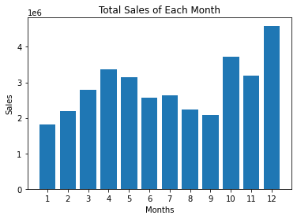

```python
mpp.bar(t_Sales.index,t_Sales.values)
mpp.title("Total Sales of Each Month")
mpp.xticks(t_Sales.index)
mpp.xlabel("Months")
mpp.ylabel("Sales")
mpp.show()
```

Which city has sold the highest product?

```python
s_Product = dataFrame.groupby('City')['Quantity Ordered'].sum()
print(s_Product)
highest_Selling_City = s_Product.idxmax()
print("The city ",highest_Selling_City," has sold the highest product")
```

```
City
 Atlanta          16602
 Austin           11153
 Boston           22528
 Dallas           16730
 Los Angeles      33289
 New York City    27932
 Portland         14053
 San Francisco    50239
 Seattle          16553
Name: Quantity Ordered, dtype: int32
The city   San Francisco  has sold the highest product
```

Which product was sold the most in overall? Illustrate it through bargraph.

```python
p_Sales = dataFrame.groupby('Product')['Quantity Ordered'].sum().sort_values(ascending= False)
p_Sales
```

```
Product
AAA Batteries (4-pack)        31017
AA Batteries (4-pack)         27635
USB-C Charging Cable          23975
Lightning Charging Cable      23217
Wired Headphones              20557
Apple Airpods Headphones      15661
Bose SoundSport Headphones    13457
27in FHD Monitor               7550
iPhone                         6849
27in 4K Gaming Monitor         6244
34in Ultrawide Monitor         6199
Google Phone                   5532
Flatscreen TV                  4819
Macbook Pro Laptop             4728
ThinkPad Laptop                4130
20in Monitor                   4129
Vareebadd Phone                2068
LG Washing Machine              666
LG Dryer                        646
Name: Quantity Ordered, dtype: int32
```

```python
print("The most sold product is ",p_Sales.idxmax(), " and sold quantity is ",p_Sales.max())
```

```
The most sold product is  AAA Batteries (4-pack)  and sold quantity is  31017
```

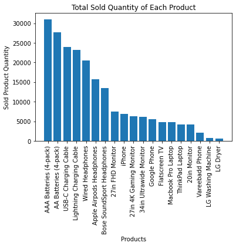

```python
mpp.bar(p_Sales.index, p_Sales.values)
mpp.xticks(rotation=90)
mpp.xlabel('Products')
mpp.ylabel('Sold Product Quantity')
mpp.title('Total Sold Quantity of Each Product')
mpp.show()
```

Write a Python program to show histogram plot of any chosen variables. Use proper labels in the graph.

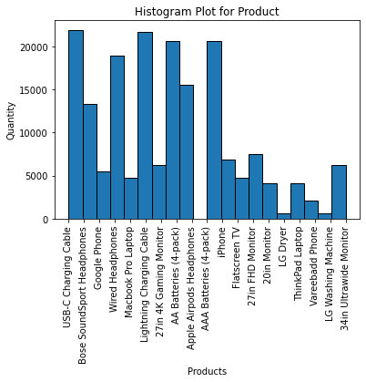

```python
mpp.hist(dataFrame["Product"],edgecolor='black', bins=20)
mpp.xticks(rotation=90)
mpp.xlabel('Products')
mpp.ylabel('Quantity')
mpp.title('Histogram Plot for Product')
mpp.show()
```